# About Dataset

## This dataset is collected from a mall's customer database and is used to analyze and segment customers based on their demographic and spending behavior. It is commonly used for unsupervised machine learning tasks like customer segmentation using K-Means clustering.

## The dataset contains 200 entries, where each row represents a unique customer. It includes the following features#:

## CustomerID: A unique identifier assigned to each customer. This is just for reference and not used for analysis.

## Gender: The gender of the customer, either "Male" or "Female". This can help identify spending patterns based on gender.

## Age: The age of the customer. This numeric feature is important as spending habits often vary with age groups.

## Annual Income (k$): This indicates the annual income of the customer in thousands of dollars. For example, 40 means $40,000 per year.

## Spending Score (1-100): This is a score assigned by the mall based on customer behavior and spending nature. A higher score means a customer is more likely to spend.

## The primary goal of analyzing this dataset is to group customers into distinct segments based on their similarities, so businesses can create targeted marketing strategies. This task is usually done through K-Means Clustering, an unsupervised learning algorithm that classifies data into K distinct clusters.

```python
# Step 1: Import required libraries
import pandas as pd
import matplotlib.pyplot as plt
import seaborn as sns
from sklearn.cluster import KMeans
from sklearn.preprocessing import StandardScaler
from sklearn.metrics import silhouette_score
import warnings
warnings.simplefilter("ignore")
```

```python
# Step 2: Load dataset
df = pd.read_csv('Mall_Customers.csv')

# Drop CustomerID since it's not useful for clustering
df_clean = df.drop(['CustomerID'], axis=1)
```

```python
# Step 3: Encode categorical 'Gender' column
df_clean['Gender'] = df_clean['Gender'].map({'Male': 0, 'Female': 1})
```

```python
# Step 4: Feature Scaling
scaler = StandardScaler()
scaled_data = scaler.fit_transform(df_clean)
```

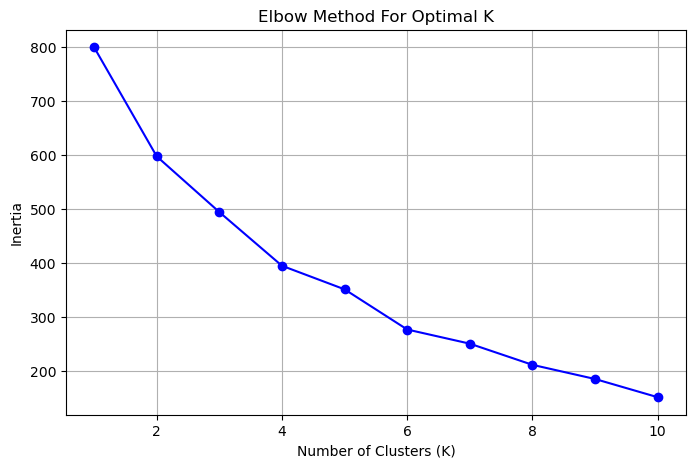

```python
# Step 5: Elbow Method to determine optimal number of clusters (K)
inertia = []
K_range = range(1, 11)

for k in K_range:
    kmeans = KMeans(n_clusters=k, random_state=42)
    kmeans.fit(scaled_data)
    inertia.append(kmeans.inertia_)

plt.figure(figsize=(8,5))
plt.plot(K_range, inertia, 'bo-')
plt.xlabel('Number of Clusters (K)')
plt.ylabel('Inertia')
plt.title('Elbow Method For Optimal K')
plt.grid(True)
plt.show()
```

```python
# Step 6: Fit KMeans with optimal K (let’s say K=5 based on elbow curve)
kmeans = KMeans(n_clusters=5, random_state=42)
labels = kmeans.fit_predict(scaled_data)

# Add cluster labels to the original DataFrame
df['Cluster'] = labels
```

```python
# Step 7: Evaluate with Silhouette Score
score = silhouette_score(scaled_data, labels)
print(f"Silhouette Score: {score:.2f}")
```

```
Silhouette Score: 0.27
```

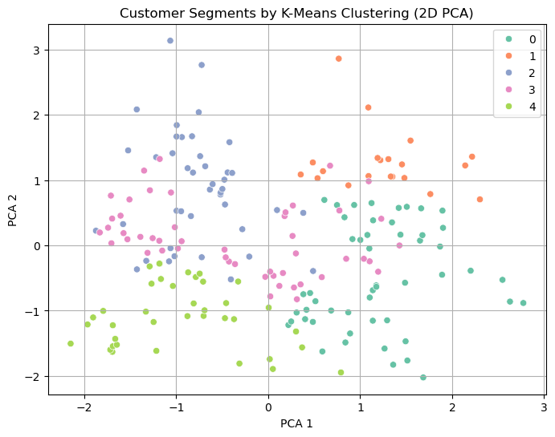

```python
# Step 8: Optional PCA for 2D visualization
from sklearn.decomposition import PCA

pca = PCA(n_components=2)
pca_data = pca.fit_transform(scaled_data)

plt.figure(figsize=(8,6))
sns.scatterplot(x=pca_data[:, 0], y=pca_data[:, 1], hue=labels, palette='Set2')
plt.title('Customer Segments by K-Means Clustering (2D PCA)')
plt.xlabel('PCA 1')
plt.ylabel('PCA 2')
plt.grid(True)
plt.show()
```